# Data Visualization, Pt. 1

### The NYT Coronavirus Data

Let’s see if we can use this template to visualize some of the COVID data we worked with last week.

First, we need to read the data into our R session. Don’t worry about the mechanics of this yet - we’ll get to it later.

```r
if (!require(readr)) install.packages('readr')
library(readr)

covidData <- read_csv('https://raw.githubusercontent.com/nytimes/covid-19-data/master/us-states.csv')
```

Looks like it read in fine. Now let’s filter out everything but Oklahoma.

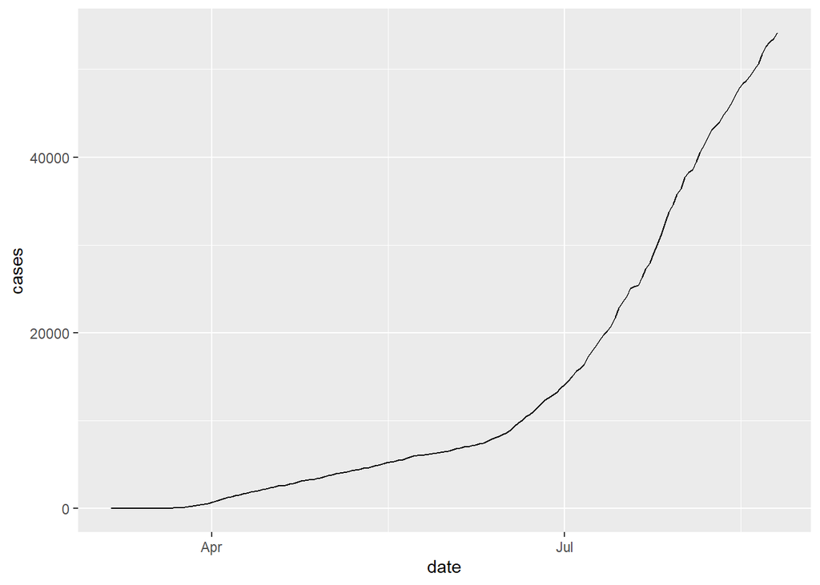

```r
covidData_OK <- covidData[covidData$state == 'Oklahoma',]

ggplot(data = covidData_OK) +
  geom_line(mapping = aes(x = date, y = cases))
```

There’s some cleaning to be done here, but we’ll learn how to do that later.

Let’s compare it to New York.

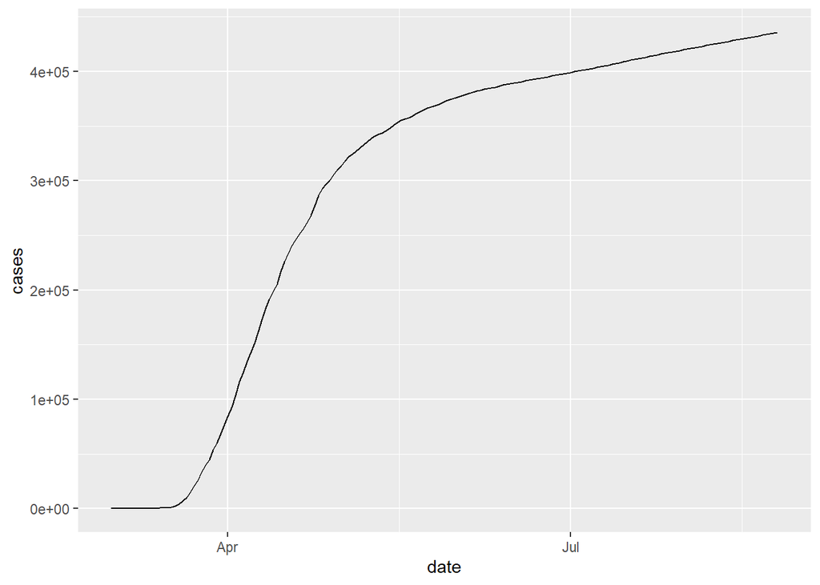

```r
covidData_NY <- covidData[covidData$state == 'New York',]

ggplot(data = covidData_NY) +
  geom_line(mapping = aes(x = date, y = cases))
```

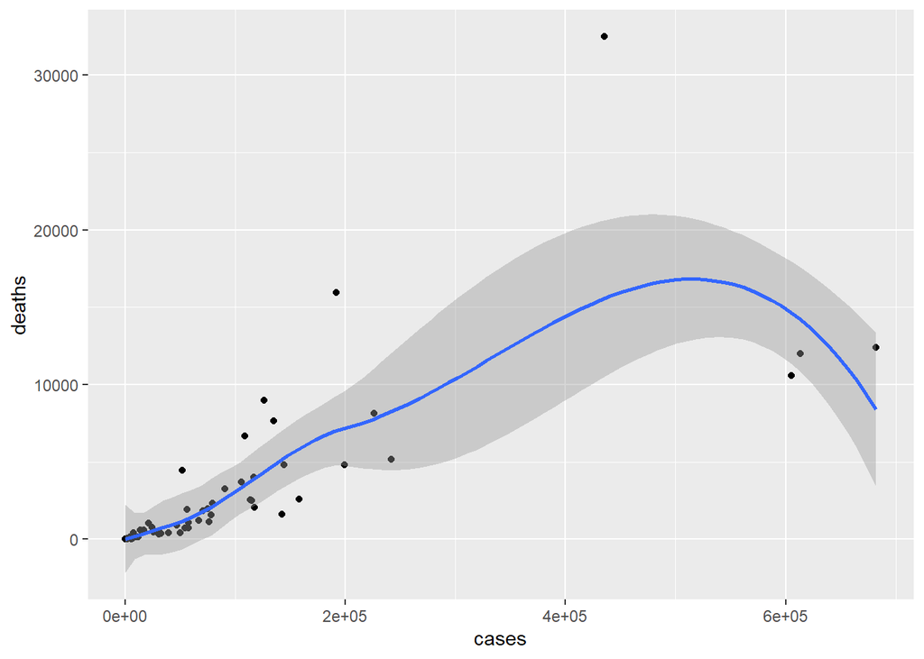

```r
covidData_yesterday <- covidData[covidData$date == as.character(Sys.Date()-1),]
ggplot(data = covidData_yesterday) +
  geom_point(mapping = aes(x = cases, y = deaths)) +
  geom_smooth(mapping = aes(x = cases, y = deaths))
```

```r
library(dplyr)
```

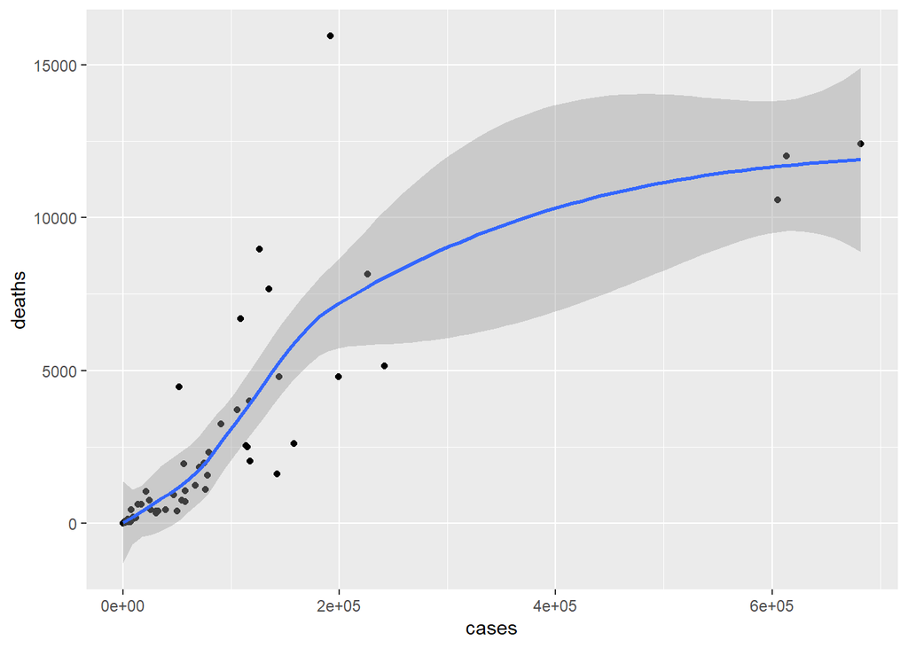

```r
covidData_yesterdayNoNY <- covidData_yesterday %>% filter(state != 'New York')

ggplot(data = covidData_yesterdayNoNY) +
  geom_point(mapping = aes(x = cases, y = deaths)) +
  geom_smooth(mapping = aes(x = cases, y = deaths))
```

There’s a weird outlier way above 30k deaths. Curious what state that is.

```r
covidData_yesterday[covidData_yesterday$deaths>30000,]
```

```
## # A tibble: 1 x 5
##   date       state    fips   cases deaths
##   <date>     <chr>    <chr>  <dbl>  <dbl>
## 1 2020-08-25 New York 36    435495  32495
```

Wonder where OK is on the graph…

```r
covidData_yesterday[covidData_yesterday$state=='Oklahoma',]
```

```
## # A tibble: 1 x 5
##   date       state    fips  cases deaths
##   <date>     <chr>    <chr> <dbl>  <dbl>
## 1 2020-08-25 Oklahoma 40    54172    744
```

So somewhere very close to the origin. Doesn’t necessarily make us safer though, it is likely just because of our relatively small population. NYC has over twice as many people than OK… maybe their situation is worse in part due to the crazy population density there.

### aesthetic mappings

I want to visualize the concentrations of covid by state, which serves to take the differences in populations out of the picture.

```r
library(readr)
library(dplyr)
stPops <- read_csv('https://raw.githubusercontent.com/drehow/CSC-201/master/2020_Fall/20200821_Analytics%20with%20Excel_2/nst-est2019-alldata.csv')
stPops <- stPops[-c(1:5,nrow(stPops)),] %>% select(NAME, POPESTIMATE2019)

covidData <- left_join(covidData,stPops, by = c('state'='NAME'))

covidData$per100k <- round(covidData$cases / covidData$POPESTIMATE2019 * 10000,2)
covidData <- covidData[!is.na(covidData$per100k),]
```

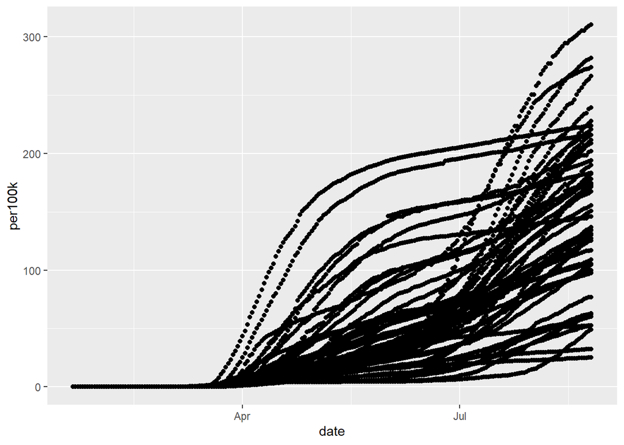

```r
ggplot(data = covidData) +
  geom_point(mapping = aes(x = date, y = per100k
                          #, group = state, color = state
                          ))
```

```r
 votes <- read_csv('https://raw.githubusercontent.com/drehow/CSC-201/master/2020_Fall/20200824_Beginning%20with%20R%20...%20Visualizing%20Data/1976-2016-president.csv')
library(scales)
library(tidyr)
votes <- votes %>%
  filter(year == 2016, writein == F, (candidate == 'Trump, Donald J.' & party =='republican') | (candidate == 'Clinton, Hillary' & party=='democrat')) %>%
  select(state, party, candidatevotes) %>%
  spread(party, candidatevotes, fill=NA)

votes <- votes %>%
  mutate(voted = ifelse(votes$democrat > votes$republican,'democrat','republican')) %>%
  select(state, voted)

covidData <- left_join(covidData, votes)
```

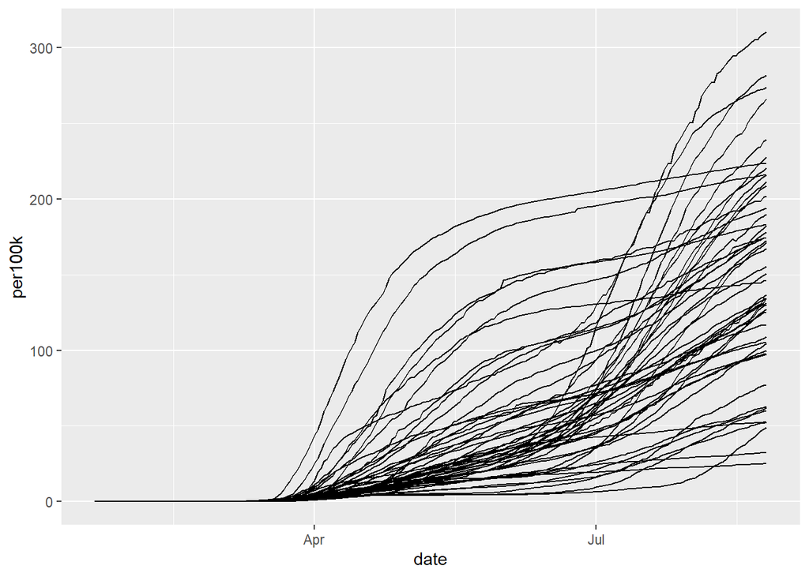

```r
covidData$population <- covidData$POPESTIMATE2019
covidData$POPESTIMATE2019 <- NULL

ggplot(data = covidData) +
  geom_line(mapping = aes(x = date, y = per100k, group = state))
```

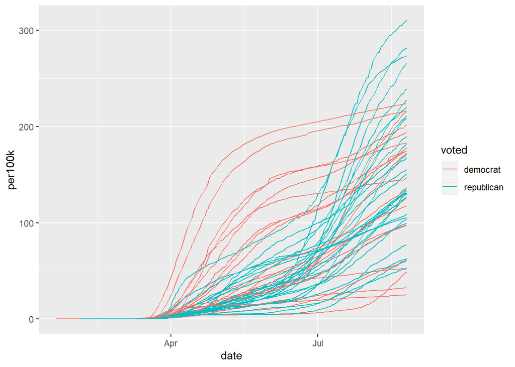

```r
ggplot(data = covidData) +
  geom_line(mapping = aes(x = date, y = per100k, group = state, color = voted))
```

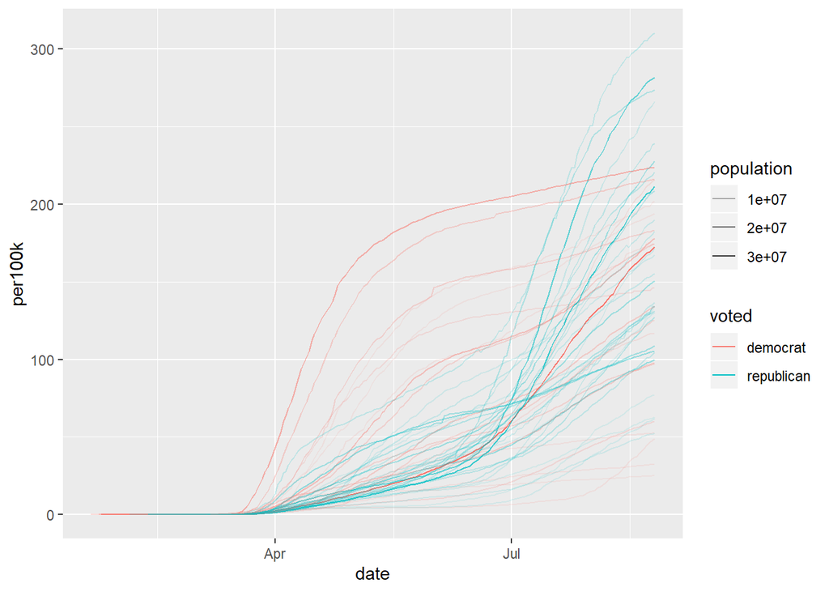

```r
ggplot(data = covidData) +
  geom_line(mapping = aes(x = date, y = per100k, group = state
                          , color = voted, alpha = population))
```

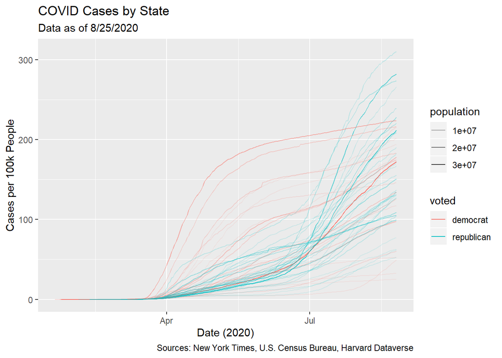

```r
 ggplot(data = covidData) +
  geom_line(mapping = aes(x = date, y = per100k, group = state
                          , color = voted, alpha = population
                          ))+
   labs(title="COVID Cases by State", subtitle="Data as of 8/25/2020", y="Cases per 100k People", x="Date (2020)", caption="Sources: New York Times, U.S. Census Bureau, Harvard Dataverse")
```

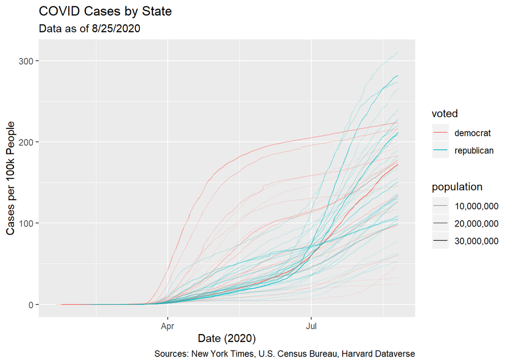

```r
ggplot(data = covidData) +
  geom_line(mapping = aes(x = date, y = per100k, group = state
                          , color = voted, alpha = population
                          ))+
   labs(title="COVID Cases by State", subtitle="Data as of 8/25/2020", y="Cases per 100k People", x="Date (2020)", caption="Sources: New York Times, U.S. Census Bureau, Harvard Dataverse") +
    scale_alpha_continuous(labels = comma)
```

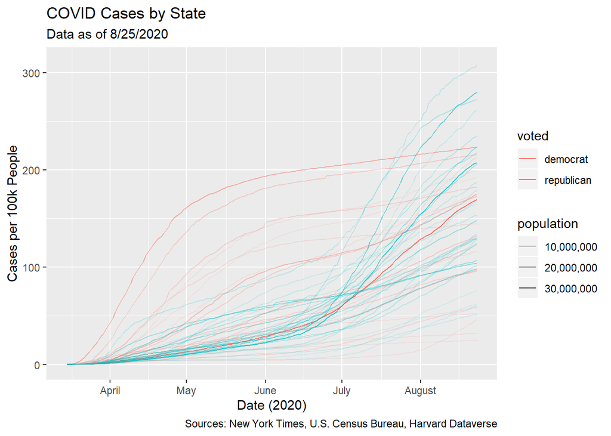

```r
ggplot(data = covidData) +
  geom_line(mapping = aes(x = date, y = per100k, group = state
                          , color = voted, alpha = population
                          ))+
  labs(title="COVID Cases by State", subtitle="Data as of 8/25/2020", y="Cases per 100k People", x="Date (2020)", caption="Sources: New York Times, U.S. Census Bureau, Harvard Dataverse") +
  scale_alpha_continuous(labels = comma) +
  scale_x_date(date_breaks = "1 month",
                labels = date_format("%B"),
                limits = as.Date(c('2020-03-15','2020-08-23')))
```

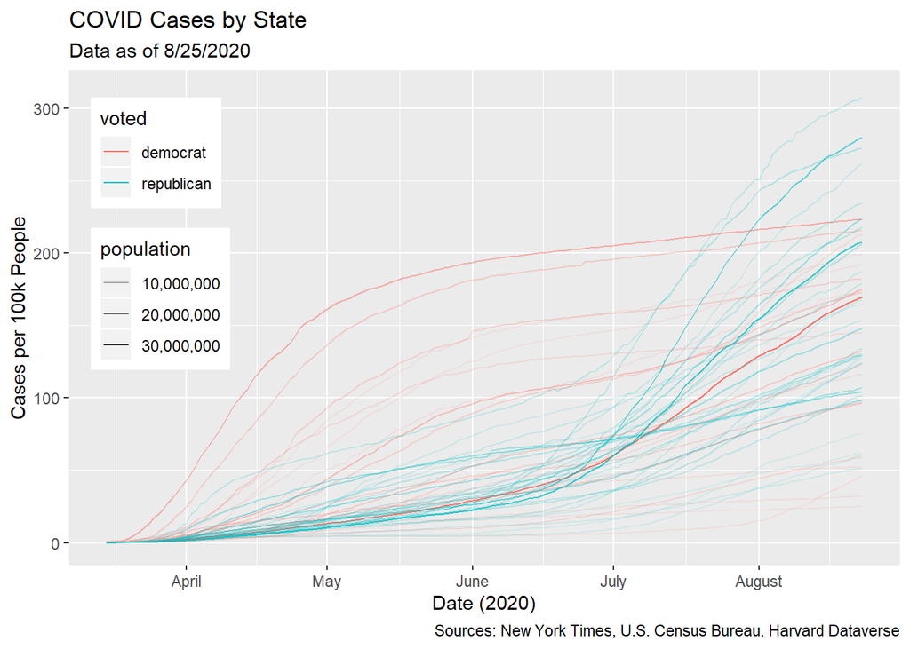

```r
ggplot(data = covidData) +
  geom_line(mapping = aes(x = date, y = per100k, group = state
                          , color = voted, alpha = population
                          ))+
  labs(title="COVID Cases by State", subtitle="Data as of 8/25/2020", y="Cases per 100k People", x="Date (2020)", caption="Sources: New York Times, U.S. Census Bureau, Harvard Dataverse") +
  scale_alpha_continuous(labels = comma) +
  scale_x_date(date_breaks = "1 month",
                labels = date_format("%B"),
                limits = as.Date(c('2020-03-15','2020-08-23'))) +
  theme(legend.position = c(0.11, 0.67))
```

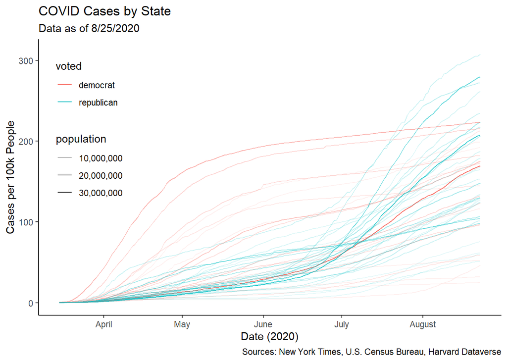

```r
ggplot(data = covidData) +
  geom_line(mapping = aes(x = date, y = per100k, group = state
                          , color = voted, alpha = population
                          ))+
  labs(title="COVID Cases by State", subtitle="Data as of 8/25/2020", y="Cases per 100k People", x="Date (2020)", caption="Sources: New York Times, U.S. Census Bureau, Harvard Dataverse") +
  scale_alpha_continuous(labels = comma) +
  scale_x_date(date_breaks = "1 month",
                labels = date_format("%B"),
                limits = as.Date(c('2020-03-15','2020-08-23'))) +
  theme_classic() +
  theme(legend.position = c(0.11, 0.67))
```

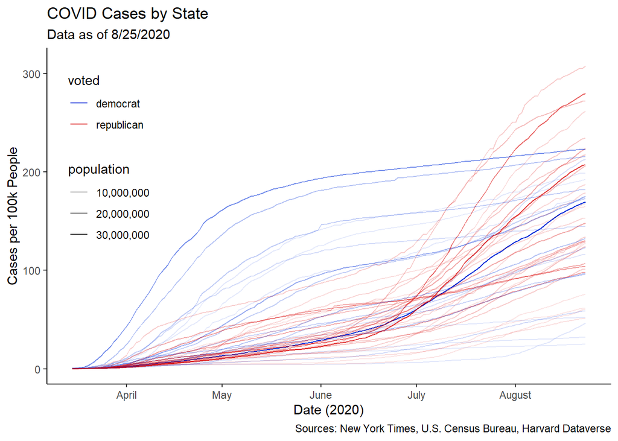

```r
ggplot(data = covidData) +
  geom_line(mapping = aes(x = date, y = per100k, group = state
                          , color = voted, alpha = population
                          )) +
 scale_alpha_continuous(labels = comma) +
 scale_x_date(date_breaks = "1 month",
                labels = date_format("%B"),
                limits = as.Date(c('2020-03-15','2020-08-23'))) +
 scale_color_manual(values=c('#002fd9','#d90000')) +
 labs(title="COVID Cases by State", subtitle="Data as of 8/25/2020", y="Cases per 100k People", x="Date (2020)", caption="Sources: New York Times, U.S. Census Bureau, Harvard Dataverse") +
 theme_classic() +
 theme(legend.position = c(0.11, 0.67))
```

```r
covidData_party <- covidData %>% group_by(date, voted) %>% summarise(per100k = mean(per100k))
```

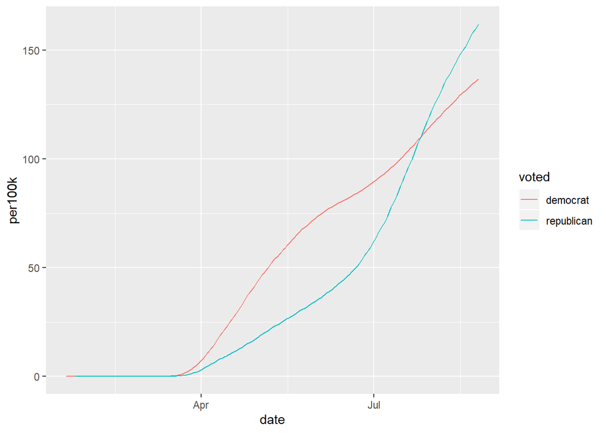

```r
ggplot(data = covidData_party) +
  geom_line(mapping = aes(x = date, y = per100k, group = voted, color = voted))
```

* shape * color * size * fill * linetype * lineend * label * family (font) * fontface

### geom_functions - cheat sheet